# Demand Forecasting Analysis

Analyze historical sales patterns to forecast future demand and better understand purchasing trends over time.

**Business Goal:** Support inventory planning and operational decision-making by predicting future product demand and identifying sales trends.

## 1. Import Libraries

Import libraries for time series analysis, forecasting, and visualization.

```python
import pandas as pd
import matplotlib.pyplot as plt
from statsmodels.tsa.arima.model import ARIMA
```

## 2. Load Dataset

```python
# load data
df = pd.read_excel("Online Retail.xlsx")
```

## 3. Data Cleaning

Prepare and clean the dataset for forecasting analysis.

```python
# clean columns
df.columns = df.columns.str.strip().str.lower()
```

## 4. Exploratory Data Analysis (EDA)

```python
# keep valid rows only
df = df[(df["quantity"] > 0) & (df["unitprice"] > 0)].copy()
```

## 5. Feature Engineering

Prepare time-based features and aggregated metrics for forecasting.

```python
# create date and sales
df["invoicedate"] = pd.to_datetime(df["invoicedate"])
df["sales"] = df["quantity"] * df["unitprice"]
df["month"] = df["invoicedate"].dt.to_period("m").astype(str)
```

## 6. Demand Forecasting Model

```python
# monthly sales
monthly_sales = (
    df.groupby("month")["sales"]
    .sum()
    .reset_index()
)
```

```python
# convert month to datetime and sort
monthly_sales["month"] = pd.to_datetime(monthly_sales["month"])
monthly_sales = monthly_sales.sort_values("month").iloc[:-1].copy()
```

```python
# moving average forecast
monthly_sales["ma_3"] = monthly_sales["sales"].rolling(3).mean()
ma_forecast = monthly_sales["sales"].tail(3).mean()

print("moving average forecast for next month:", round(ma_forecast, 2))
```

```
moving average forecast for next month: 1241021.93
```

```python
# arima forecast
ts = monthly_sales.set_index("month")["sales"]
model = ARIMA(ts, order=(1, 1, 1))
model_fit = model.fit()
arima_forecast = model_fit.forecast(steps=1)

print("arima forecast for next month:", round(arima_forecast.iloc[0], 2))
```

```
arima forecast for next month: 1461941.3
```

```python
# next month for forecast points
next_month = monthly_sales["month"].max() + pd.DateOffset(months=1)
```

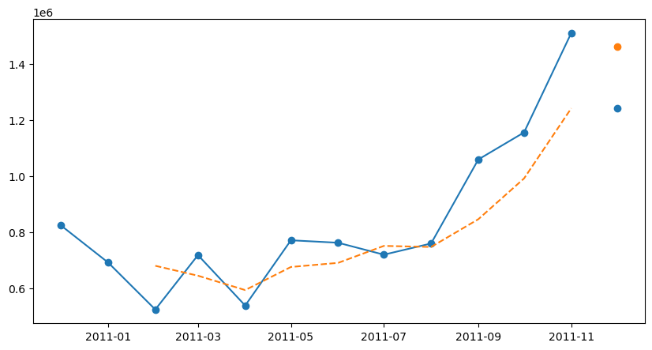

```python
# plot
plt.figure(figsize=(10, 5))
plt.plot(monthly_sales["month"], monthly_sales["sales"], marker="o", label="actual")
plt.plot(monthly_sales["month"], monthly_sales["ma_3"], linestyle="--", label="ma_3")
plt.scatter(next_month, ma_forecast, label="ma_forecast")
plt.scatter(next_month, arima_forecast.iloc[0], label="arima_forecast")
```

## 10. Export CSVs for Tableau Dashboard

Export forecasting results to CSV files for Tableau visualization.

```python
import os
os.makedirs("../outputs", exist_ok=True)

# Monthly sales with 3-month moving average
monthly_out = monthly_sales.copy()
monthly_out["month"] = monthly_out["month"].dt.strftime("%Y-%m")
monthly_out.to_csv("../outputs/monthly_sales.csv", index=False)

# Forecast comparison: MA vs ARIMA
forecast_df = pd.DataFrame({
    "month": [next_month.strftime("%Y-%m")],
    "ma_forecast": [round(ma_forecast, 2)],
    "arima_forecast": [round(arima_forecast.iloc[0], 2)]
})
forecast_df.to_csv("../outputs/forecast_comparison.csv", index=False)

print("Saved:")
print("  ../outputs/monthly_sales.csv -", len(monthly_out), "months")
print("  ../outputs/forecast_comparison.csv")
print()
print(forecast_df)
```

```
Saved:
  ../outputs/monthly_sales.csv - 12 months
  ../outputs/forecast_comparison.csv

     month  ma_forecast  arima_forecast
0  2011-12   1241021.93       1461941.3
```

## 11. Model Accuracy Evaluation (Holdout Test)

The forecasts above are next-month projections with no ground truth to score against. To measure accuracy honestly, we hold out the **last 3 months** as a test set, refit on the earlier months, and compare **walk-forward one-step-ahead** forecasts for both models using MAPE, RMSE, and MAE.

> **Caveat:** only 12 complete months are available (9 train / 3 test), so these numbers are illustrative, not statistically robust.

```python
# Model accuracy on a held-out test set (proper train/test split)
import numpy as np
from statsmodels.tsa.arima.model import ARIMA

ts = monthly_sales.set_index("month")["sales"]

N_TEST = 3  # hold out the last 3 months
train, test = ts.iloc[:-N_TEST], ts.iloc[-N_TEST:]
print(f"Months available: {len(ts)} | Train: {len(train)} | Test: {len(test)} "
      f"({test.index.min():%Y-%m} -> {test.index.max():%Y-%m})")

def _metrics(actual, pred):
    actual, pred = np.asarray(actual, float), np.asarray(pred, float)
    mae = np.mean(np.abs(actual - pred))
    rmse = np.sqrt(np.mean((actual - pred) ** 2))
    mape = np.mean(np.abs((actual - pred) / actual)) * 100
    return mape, rmse, mae

# Moving-average baseline: one-step-ahead = mean of the prior 3 actual months
ma_preds = [ts.iloc[i - 3:i].mean() for i in range(len(ts) - N_TEST, len(ts))]

# ARIMA(1,1,1): walk-forward one-step-ahead, refit at each step
arima_preds, history = [], list(train)
for actual in test:
    fit = ARIMA(history, order=(1, 1, 1)).fit()
    arima_preds.append(fit.forecast(steps=1)[0])
    history.append(actual)

ma = _metrics(test.values, ma_preds)
ar = _metrics(test.values, arima_preds)

eval_results = pd.DataFrame(
    {"MAPE_%": [ma[0], ar[0]], "RMSE": [ma[1], ar[1]], "MAE": [ma[2], ar[2]]},
    index=["Moving Average (3-mo)", "ARIMA(1,1,1)"],
).round(2)
print(eval_results)
print(f"\nARIMA vs baseline -> MAPE {(ma[0]-ar[0])/ma[0]*100:+.1f}%, "
      f"RMSE {(ma[1]-ar[1])/ma[1]*100:+.1f}%, MAE {(ma[2]-ar[2])/ma[2]*100:+.1f}%")
```

```
Months available: 12 | Train: 9 | Test: 3 (2011-09 -> 2011-11)
```

```
                       MAPE_%       RMSE        MAE
Moving Average (3-mo)   30.20  392385.74  379937.82
ARIMA(1,1,1)            23.65  303230.83  293270.58

ARIMA vs baseline -> MAPE +21.7%, RMSE +22.7%, MAE +22.8%
```